# A Thiopurine-like Mutagenic Process Defines TGCT Subtypes

Tongwu Zhang

2025-11-17

## 1 Overview

This R Markdown document reproduces the main analyses and figures for TCGA-TGCT WGS dataset

Manuscript title: A Thiopurine-like Mutagenic Process Defines TGCT Subtype

## 2 Fig. 6: Germ Cell-Like Transcriptomic Program and Unique APOBEC Mutagenesis Suppression in TGCTs.

## 3 Load Required Libraries and Set Plotting Styles

(You may need to install some packages if missing)

```r
source('functions/Sherlock_functions.R')

set_wd()
```

```
## [1] "/Users/zhangt8/NIH-Work/Earl_Stadtman_Inverstigator/Projects/TCGA_TGCT/biowulf/Rmarkdown"
## [1] "ok"
```

```r
libztw()
pdfhr()
pdfhr2()

library(ggpp)
conflicts_prefer(ggplot2::annotate)
library(ggrepel)

# Load R object WGS analysis results --------------------------------------

load('data/wgs_data.RData')
load('data/wgs_clinical.RData')
load('data/ngspurity_data.RData')
```

## 4 Fig. 6a

Differential enrichment of Hallmark gene sets in TGCTs versus other TCGA tumor types using ssGSEA scores. Enriched pathways include cell cycle, DNA repair, and spermatogenesis; depleted pathways include metabolic and immune-related processes. Circle size indicates −log10 FDR from two-sided Wilcoxon rank-sum tests; color denotes median ssGSEA score enrichment in TGCTs. Benjamini–Hochberg correction was applied.

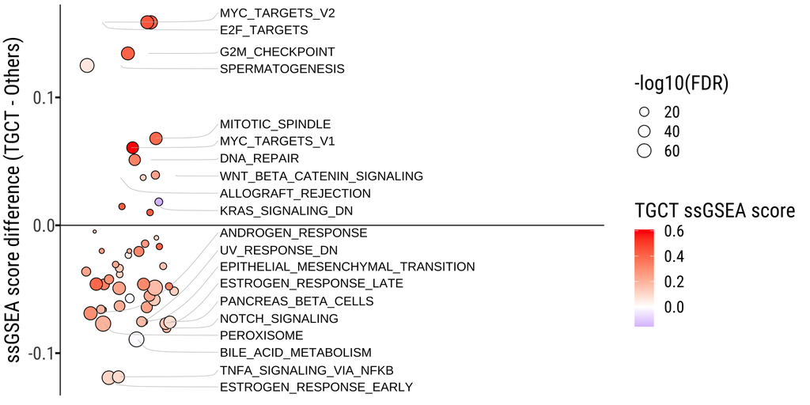

```r
load('data/ssGSEA.RData')
load('data/wgs_data.RData')

pdata <- ssgsea_results_h %>%
  left_join(barcode2study) %>%
  left_join(
    wgs_data %>%
      mutate(TCGA_Barcode = str_sub(Tumor_Barcode, 1, 15)) %>%
      select(TCGA_Barcode, Subtype)
  ) %>%
  mutate(
    Group = if_else(
      Study == 'TGCT',
      if_else(is.na(Subtype), 'TGCT', Subtype),
      'Others'
    )
  )


## comparing other TCGA tumors as a whole
pdata2 <- pdata %>%
  mutate(Group = if_else(Study == 'TGCT', 'TGCT', 'Others'))

pdata3 <- pdata2 %>%
  group_by(Pathway) %>%
  do(tidy(wilcox.test(ssGSEA_socre ~ Group, data = .))) %>%
  ungroup() %>%
  mutate(FDR = p.adjust(p.value, method = 'BH'))

# #if adjusted by purity
# pdata3 <- pdata2 %>%
#   left_join(pureedata %>% rename(TCGA_Barcode=Barcode)) %>% filter(!is.na(Purity)) %>%
#   group_by(Pathway) %>%
#   do(tidy(lm(ssGSEA_socre ~ Group + Purity, data = .))) %>%
#   ungroup() %>%
#   filter(term=='GroupTGCT') %>%
#   mutate(FDR = p.adjust(p.value, method = 'BH'))
#

tmp <- pdata2 %>%
  group_by(Pathway, Group) %>%
  summarise(score = median(ssGSEA_socre)) %>%
  ungroup() %>%
  pivot_wider(names_from = Group, values_from = score) %>%
  mutate(FC = TGCT - Others)

pdata3 <- pdata3 %>%
  left_join(tmp) %>%
  mutate(Pathway = str_remove(Pathway, '^HALLMARK_')) %>%
  arrange(FC)

jitter_pos1 <- position_jitter(width = .1, height = 0, seed = 1)
jitter_pos2 <- position_jitternudge(width = .1, height = 0, seed = 1, x = 0.2)

library(ggpp)
library(ggrepel)

pdata3 %>%
  ggplot(aes(x = 1, y = FC)) +
  geom_hline(yintercept = 0, col = 'gray20') +
  geom_point(
    aes(size = -log10(FDR), fill = TGCT),
    pch = 21,
    position = jitter_pos1
  ) +
  scale_x_continuous(limits = c(0.9, 2)) +
  scale_fill_gradient2(
    midpoint = 0,
    low = 'blue',
    high = 'red',
    mid = 'white'
  ) +
  #scale_size_binned_area()+
  labs(
    x = NULL,
    y = 'ssGSEA score difference (TGCT - Others)',
    fill = 'TGCT ssGSEA score'
  ) +
  theme_ipsum_rc(
    base_size = 18,
    axis = F,
    grid = F,
    axis_title_just = 'm',
    axis_text_size = 16,
    axis_title_size = 18
  ) +
  theme(
    plot.margin = margin(4, 4, 4, 4),
    axis.text.x = element_blank(),
    axis.line.x = element_blank(),
    axis.line.y = element_line(size = 0.5, colour = 'gray20'),
    axis.ticks.y = element_line()
  ) +
  geom_text_repel(
    data = pdata3 %>%
      arrange(desc(abs(FC))) %>%
      group_by(FC > 0) %>%
      slice(1:10),
    aes(label = Pathway),
    color = 'black', #color=if_else(FC>0,'red4','blue4')
    position = jitter_pos2,
    force = 2,
    #nudge_x           = 0.2,
    direction = "y",
    hjust = 0,
    segment.size = 0.2,
    segment.color = 'gray',
    segment.curvature = -0.1
  )
```

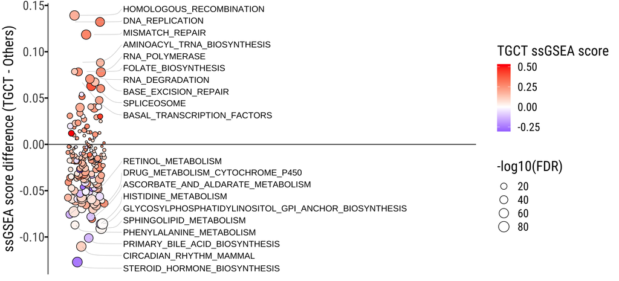

```r
pdata <- ssgsea_results_kegg %>%
  left_join(barcode2study) %>%
  left_join(
    wgs_data %>%
      mutate(TCGA_Barcode = str_sub(Tumor_Barcode, 1, 15)) %>%
      select(TCGA_Barcode, Subtype)
  ) %>%
  mutate(
    Group = if_else(
      Study == 'TGCT',
      if_else(is.na(Subtype), 'TGCT', Subtype),
      'Others'
    )
  )


## comparing other TCGA tumors as a whole
pdata2 <- pdata %>%
  mutate(Group = if_else(Study == 'TGCT', 'TGCT', 'Others'))

pdata3 <- pdata2 %>%
  group_by(Pathway) %>%
  do(tidy(wilcox.test(ssGSEA_socre ~ Group, data = .))) %>%
  ungroup() %>%
  mutate(FDR = p.adjust(p.value, method = 'BH'))

# #if adjusted by purity
# pdata3 <- pdata2 %>%
#   left_join(pureedata %>% rename(TCGA_Barcode=Barcode)) %>% filter(!is.na(Purity)) %>%
#   group_by(Pathway) %>%
#   do(tidy(lm(ssGSEA_socre ~ Group + Purity, data = .))) %>%
#   ungroup() %>%
#   filter(term=='GroupTGCT') %>%
#   mutate(FDR = p.adjust(p.value, method = 'BH'))
#

tmp <- pdata2 %>%
  group_by(Pathway, Group) %>%
  summarise(score = median(ssGSEA_socre)) %>%
  ungroup() %>%
  pivot_wider(names_from = Group, values_from = score) %>%
  mutate(FC = TGCT - Others)

pdata3 <- pdata3 %>%
  left_join(tmp) %>%
  mutate(Pathway = str_remove(Pathway, '^KEGG_')) %>%
  arrange(FC)

jitter_pos1 <- position_jitter(width = .1, height = 0, seed = 1)
jitter_pos2 <- position_jitternudge(width = .1, height = 0, seed = 1, x = 0.2)

library(ggpp)
library(ggrepel)

pdata3 %>%
  ggplot(aes(x = 1, y = FC)) +
  geom_hline(yintercept = 0, col = 'gray20') +
  geom_point(
    aes(size = -log10(FDR), fill = TGCT),
    pch = 21,
    position = jitter_pos1
  ) +
  scale_x_continuous(limits = c(0.9, 3)) +
  scale_fill_gradient2(
    midpoint = 0,
    low = 'blue',
    high = 'red',
    mid = 'white'
  ) +
  #scale_size_binned_area()+
  labs(
    x = NULL,
    y = 'ssGSEA score difference (TGCT - Others)',
    fill = 'TGCT ssGSEA score'
  ) +
  theme_ipsum_rc(
    base_size = 18,
    axis = F,
    grid = F,
    axis_title_just = 'm',
    axis_text_size = 16,
    axis_title_size = 18
  ) +
  theme(
    plot.margin = margin(4, 4, 4, 4),
    axis.text.x = element_blank(),
    axis.line.x = element_blank(),
    axis.line.y = element_line(size = 0.5, colour = 'gray20'),
    axis.ticks.y = element_line()
  ) +
  geom_text_repel(
    data = pdata3 %>%
      arrange(desc(abs(FC))) %>%
      group_by(FC > 0) %>%
      slice(1:10),
    aes(label = Pathway),
    color = 'black', #color=if_else(FC>0,'red4','blue4')
    position = jitter_pos2,
    force = 2,
    #nudge_x           = 0.2,
    direction = "y",
    hjust = 0,
    segment.size = 0.2,
    segment.color = 'gray',
    segment.curvature = -0.1
  )
```

## 5 Fig. 6c

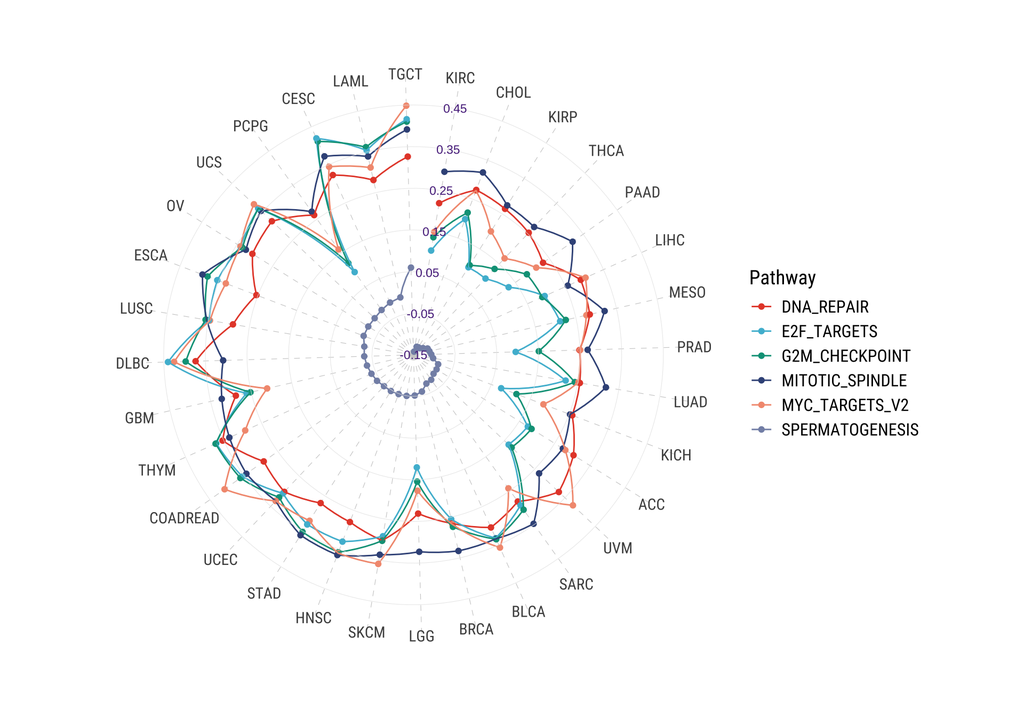

```r
pdata <- ssgsea_results_h %>%
  left_join(barcode2study) %>%
  left_join(
    wgs_data %>%
      mutate(TCGA_Barcode = str_sub(Tumor_Barcode, 1, 15)) %>%
      select(TCGA_Barcode, Subtype)
  ) %>%
  mutate(
    Group = if_else(
      Study == 'TGCT',
      if_else(is.na(Subtype), 'TGCT', Subtype),
      'Others'
    )
  )

pdata2 <- pdata %>%
  filter(
    Pathway %in%
      c(
        "HALLMARK_MYC_TARGETS_V2",
        "HALLMARK_E2F_TARGETS",
        "HALLMARK_G2M_CHECKPOINT",
        "HALLMARK_SPERMATOGENESIS",
        "HALLMARK_MITOTIC_SPINDLE",
        "HALLMARK_DNA_REPAIR"
      )
  ) %>%
  group_by(Study, Pathway) %>%
  summarise(score = median(ssGSEA_socre)) %>%
  ungroup() %>%
  arrange(score) %>%
  mutate(Study = fct_inorder(Study)) %>%
  mutate(Pathway = str_remove(Pathway, '^HALLMARK_'))

# polar plot

ggplot(
  data = pdata2,
  aes(x = (Study), y = score, group = Pathway, color = Pathway)
) +
  #ylim(0, NA)+
  geom_point(stat = 'identity') +
  geom_line(linewidth = 0.5) +
  coord_polar(start = -pi * 1 / 24 + 0.2) +
  theme_ipsum_rc(base_size = 11, ticks = FALSE, grid = "Xx") +
  scale_color_npg() +
  theme(
    axis.text.y = element_blank(),
    axis.title.x = element_blank(),
    axis.title.y = element_blank(),
    panel.grid = element_line(linetype = 2)
  ) +
  geom_hline(
    yintercept = seq(-0.15, 0.45, 0.1),
    color = "gray90",
    size = 0.15
  ) +
  annotate(
    'text',
    x = 1,
    y = seq(-0.15, 0.45, 0.1),
    label = seq(-0.15, 0.45, 0.1),
    size = 3,
    col = '#542788'
  ) +
  #guides(color="none")+
  theme(
    legend.position = 'right',
    legend.text = element_text(size = 12),
    legend.title = element_text(size = 14)
  )
```

## 6 Fig. 6d

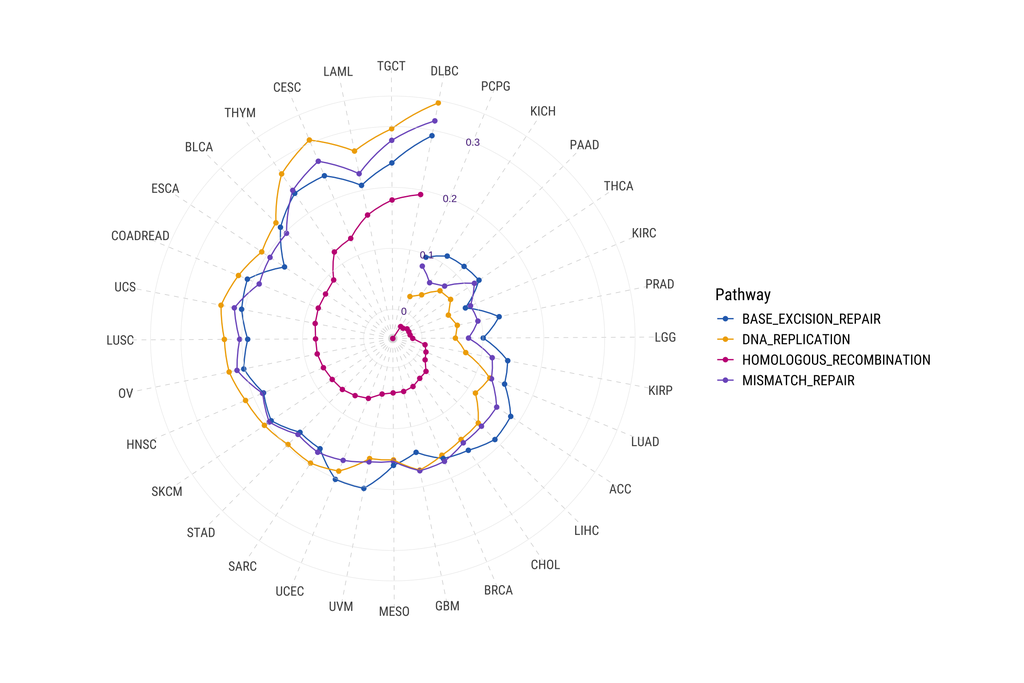

```r
pdata <- ssgsea_results_kegg %>%
  left_join(barcode2study) %>%
  left_join(
    wgs_data %>%
      mutate(TCGA_Barcode = str_sub(Tumor_Barcode, 1, 15)) %>%
      select(TCGA_Barcode, Subtype)
  ) %>%
  mutate(
    Group = if_else(
      Study == 'TGCT',
      if_else(is.na(Subtype), 'TGCT', Subtype),
      'Others'
    )
  )


pdata2 <- pdata %>%
  filter(
    Pathway %in%
      c(
        'KEGG_BASE_EXCISION_REPAIR',
        'KEGG_HOMOLOGOUS_RECOMBINATION',
        'KEGG_MISMATCH_REPAIR',
        'KEGG_DNA_REPLICATION'
      )
  ) %>%
  group_by(Study, Pathway) %>%
  summarise(score = median(ssGSEA_socre)) %>%
  ungroup() %>%
  arrange(score) %>%
  mutate(Study = fct_inorder(Study)) %>%
  mutate(Pathway = str_remove(Pathway, '^KEGG_'))

# polar plot

ggplot(
  data = pdata2,
  aes(x = (Study), y = score, group = Pathway, color = Pathway)
) +
  #ylim(0, NA)+
  geom_point(stat = 'identity') +
  geom_line(linewidth = 0.5) +
  coord_polar(start = -pi * 1 / 24 + 0.42, ) +
  theme_ipsum_rc(base_size = 11, ticks = FALSE, grid = "Xx") +
  scale_color_bmj() +
  theme(
    axis.text.y = element_blank(),
    axis.title.x = element_blank(),
    axis.title.y = element_blank(),
    panel.grid = element_line(linetype = 2)
  ) +
  geom_hline(
    yintercept = c(0, 0.1, 0.2, 0.3, 0.35),
    color = "gray90",
    size = 0.15
  ) +
  annotate(
    'text',
    x = 1,
    y = c(0, 0.1, 0.2, 0.3),
    label = c(0, 0.1, 0.2, 0.3),
    size = 3,
    col = '#542788'
  ) +
  #guides(color="none")+
  theme(
    legend.position = 'right',
    legend.text = element_text(size = 12),
    legend.title = element_text(size = 14)
  )
```

## 7 Fig. 6e

UNG (uracil DNA glycosylase) mRNA expression across TCGA tumors, with TGCTs showing the highest levels and seminomas higher than non-seminomas. P-values from two-sided Wilcoxon rank-sum tests are shown above boxplots. Boxplots display median, IQR, and whiskers extending to 1.5× IQR.

```r
load('data/tcga_expdata_all.RData',verbose = T)
```

```
## Loading objects:
##   expdata
```

```r
pdata <- expdata %>% filter(Gene=='UNG')
mvalue <- pdata %>% group_by(Study) %>% summarise(mvalue=median(log2(RSEM+1)))
tmp <- pdata %>% select(Study,TCGA_Barcode) %>% unique() %>% count(Study) %>% mutate(StudyLab=paste0(Study,' (',n,')'))

p1 <- pdata %>%
  left_join(tmp) %>%
  left_join(mvalue) %>%
  mutate(StudyLab=fct_reorder(StudyLab,RSEM)) %>%
  ggplot(aes(StudyLab,log2(RSEM+1),fill=mvalue))+
  geom_boxplot(outlier.shape = NA,width=0.7,size=0.25)+
  scale_y_continuous(breaks = pretty_breaks(n=7),limits = c(7.5,13.5))+
  scale_fill_viridis_c()+
  labs(y='UNG mRNA expression\nlog2(RNA Seq V2 RSEM + 1)',x='',color='Group')+
  theme_ipsum_rc(axis_title_just = 'm',axis_title_size = 14,ticks = T,grid = 'Y')+
  theme(axis.text.x = element_text(angle = 90,hjust = 1,vjust = 1),panel.spacing = unit(0.4, "lines"),strip.background = element_blank(),strip.text = element_text(hjust = 0.5),plot.margin = margin(4,4,-6,4))+
  guides(fill="none")+
  panel_border(color = 'black',linetype = 1)+  panel_border(color = 'black',size = 0.5)+
  theme(legend.position = 'none')

# by subtype

pdata2 <- pdata %>%
  filter(Study=='TGCT') %>%
  left_join(wgs_data %>% select(Subtype,Subject)) %>%
  mutate(Study=Subtype) %>%
  filter(!is.na(Subtype))

my_comparisons <-  list(c('Seminoma','Non-Seminoma'))

stat.test <- pdata2 %>%
  mutate(RSEM=log2(RSEM+1)) %>%
  rstatix::wilcox_test(RSEM ~ Subtype, comparisons = my_comparisons) %>%
  rstatix::add_xy_position(x = "Subtype") %>%
  mutate(myformatted.p = sprintf("P = %.2e",p)) %>%
  mutate(SubtypeLab = NA)

stat.test
```

```
## # A tibble: 1 × 13
##   .y.   group1   group2      n1    n2 statistic        p y.position groups  xmin
##   <chr> <chr>    <chr>    <int> <int>     <dbl>    <dbl>      <dbl> <list> <dbl>
## 1 RSEM  Seminoma Non-Sem…    59    80      4105 1.05e-13       13.3 <chr>      1
## # ℹ 3 more variables: xmax <dbl>, myformatted.p <chr>, SubtypeLab <lgl>
```

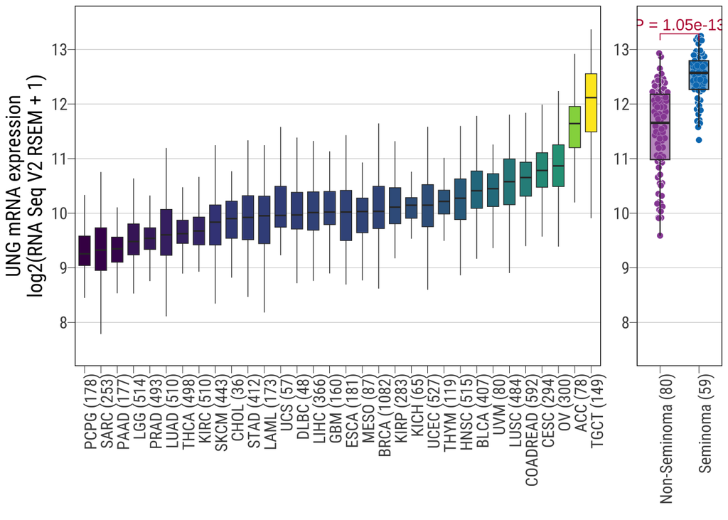

```r
tmp <- pdata2 %>% select(Subtype,TCGA_Barcode) %>% unique() %>% count(Subtype) %>% mutate(SubtypeLab=paste0(Subtype,' (',n,')'))

p2 <- pdata2 %>%
  left_join(tmp) %>%
  ggplot(aes(SubtypeLab,log2(RSEM+1),fill=SubtypeLab))+
  ggbeeswarm::geom_quasirandom(pch=21,size=2,width = 0.2,color="white",stroke=0.2)+
  geom_boxplot(width=0.5,outlier.shape = NA,alpha =0.6,size=0.4)+
  scale_fill_manual(values = rev(as.character(subtypecol)))+
  scale_y_continuous(breaks = pretty_breaks(n = 7),limits = c(7.5,13.5))+
  labs(y=NULL,x='',color='Group')+
  theme_ipsum_rc(axis_title_just = 'm',axis_title_size = 14,ticks = T,grid = 'Y')+
  theme(axis.text.x = element_text(angle = 90,hjust = 1,vjust = 1),panel.spacing = unit(0.4, "lines"),strip.background = element_blank(),strip.text = element_text(hjust = 0.5),plot.margin = margin(4,4,-6,4))+
  guides(fill="none")+
  panel_border(color = 'black',linetype = 1)+  panel_border(color = 'black',size = 0.5)+
  theme(legend.position = 'none')+
  stat_pvalue_manual(stat.test, label = "myformatted.p",color = ncicolpal[1])

plot_grid(p1,p2,align = 'h',nrow = 1,axis = 'tb',rel_widths = c(5,1))
```

## 8 Fig. 6f

```r
load('data/tcga_expdata_all.RData',verbose = T)
```

```
## Loading objects:
##   expdata
```

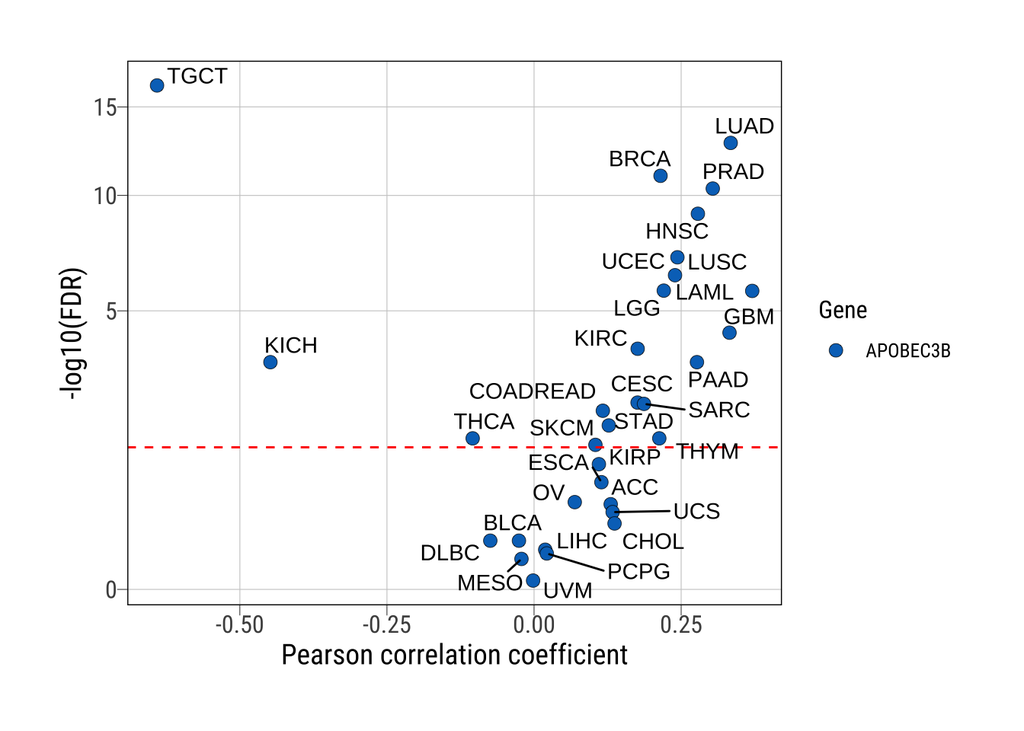

```r
apobec_genes <- c('AICDA','APOBEC2','APOBEC3A','APOBEC3B','APOBEC3C','APOBEC3D','APOBEC3E','APOBEC3F','APOBEC3G','APOBEC3H','APOBEC4')
tdata <- expdata %>%
  filter(Gene %in% apobec_genes) %>%
  left_join(
    expdata %>% filter(Gene == 'UNG') %>% select(TCGA_Barcode,Subject,Study,UNG=RSEM)
  )

pdata <- tdata %>%
  group_by(Study,Gene) %>%
  do(tidy(cor.test(log2(.$UNG+1),log2(.$RSEM+1)))) %>%
  arrange(p.value) %>%
  group_by(Gene) %>%
  mutate(FDR=p.adjust(p.value,method='BH')) %>%
  arrange(FDR)

pdata %>%
  filter(Gene=='APOBEC3B') %>%
  ggplot(aes(estimate,-log10(FDR),fill=Gene))+
  geom_point(pch=21,stroke=0.2,size=3)+
  geom_hline(yintercept = -log10(0.05),linetype=2,col='red',size=0.5)+
  ggrepel::geom_text_repel(aes(label=Study))+
  scale_fill_jco()+
  scale_y_sqrt()+
  theme_ipsum_rc(base_size = 12,axis_title_just = 'm',axis_title_size = 14,grid="XY",ticks = T)+
  panel_border(color = 'black',size = 0.5)+
  #theme(legend.position = 'none')+
  labs(x='Pearson correlation coefficient', y = '-log10(FDR)')
```

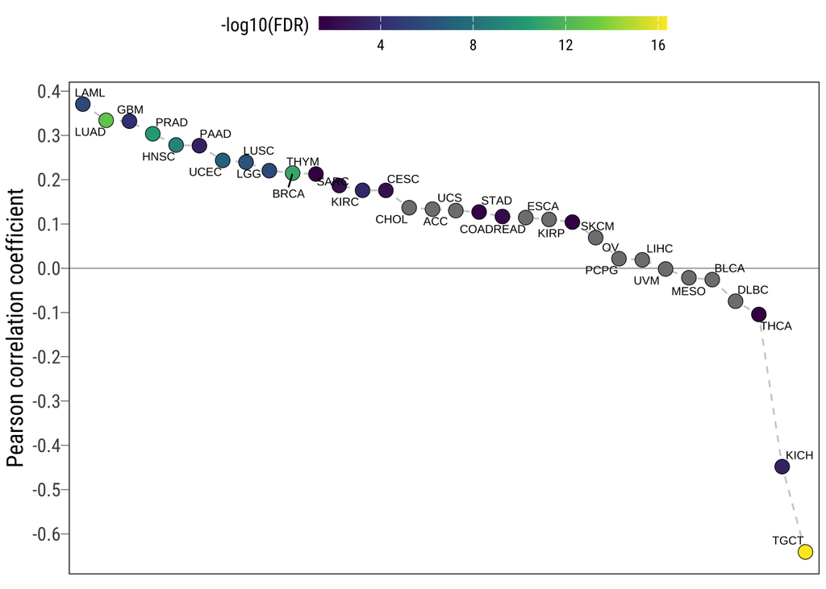

```r
pdata %>%
  filter(Gene=='APOBEC3B') %>%
  mutate(FDR=if_else(FDR<0.05,FDR,NA_real_)) %>%
  mutate(Study=fct_rev(fct_reorder(Study,estimate))) %>%
  ggplot(aes(Study,estimate,fill=-log10(FDR),group=1))+
  geom_hline(yintercept = 0,col='gray40',linewidth=0.2)+
  geom_line(colour = '#cccccc',linetype=2)+
  geom_point(pch=21,stroke=0.3,size=4)+
  scale_y_continuous(breaks = pretty_breaks(n = 8))+
  ggrepel::geom_text_repel(aes(label=Study),size=2.5)+
  scale_fill_viridis_c()+
  labs(x=NULL,y='Pearson correlation coefficient',fill="-log10(FDR)\n")+
  theme_ipsum_rc(axis_title_just = 'm',axis_title_size = 14,ticks = T,grid = F)+
  theme(axis.text.x = element_blank(),panel.spacing = unit(0.4, "lines"),strip.background = element_blank(),strip.text = element_text(hjust = 0.5),plot.margin = margin(4,4,4,4),axis.ticks.x = element_blank())+
  theme(legend.position = 'top',legend.key.width = unit(1.5,'cm'),legend.key.height = unit(0.3,'cm'))+
  panel_border(color = 'black',size=0.5)+
  theme(legend.position = 'top')
```

## 9 Fig. 6g

Scatterplot of negative association between APOBEC3B and UNG mRNA expression in TGCTs. Pearson R and P-value are shown below.

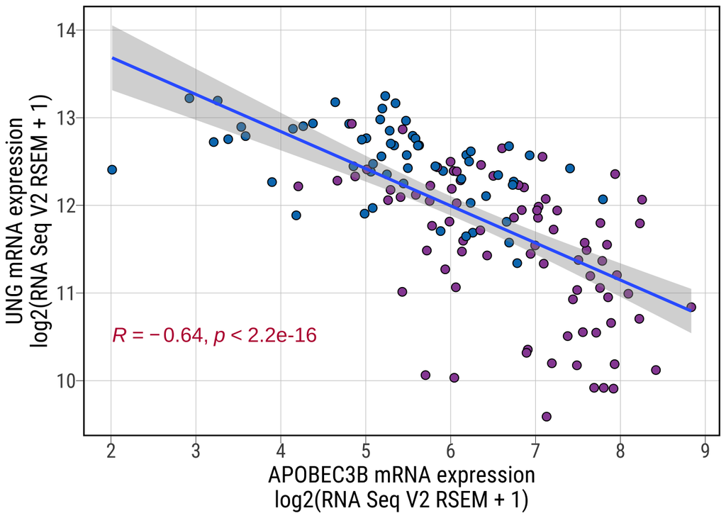

```r
tdata <- expdata %>%
  filter(Gene %in% apobec_genes) %>%
  left_join(
    expdata %>% filter(Gene == 'UNG') %>% select(TCGA_Barcode,Subject,Study,UNG=RSEM)
  )
tdata %>%
  filter(Gene=='APOBEC3B',Study=='TGCT') %>%
  left_join(wgs_data) %>%
  filter(!is.na(Subtype)) %>%
  ggplot(aes(log2(RSEM+1),log2(UNG+1)))+
  geom_point(pch=21,size=2.5,aes(fill=Subtype))+
  stat_smooth(method = "lm") +
  stat_cor(size=5,col=ncicolpal[1],label.y =10.5) +
  scale_fill_manual(values = subtypecol) +
  scale_y_continuous(breaks = pretty_breaks(n = 7))+
  scale_x_continuous(breaks = pretty_breaks(n = 7))+
  labs(x='APOBEC3B mRNA expression\nlog2(RNA Seq V2 RSEM + 1)',y='UNG mRNA expression\nlog2(RNA Seq V2 RSEM + 1)')+
  theme_ipsum_rc(axis_text_size = 14,axis_title_just = 'm',axis_title_size = 16,grid = 'XY',ticks = T)+
  panel_border(color = 'black')+
  theme(#axis.text.x = element_blank(),
    panel.spacing = unit(0.4,'cm'),
    #axis.ticks.x = element_blank(),
    plot.margin = margin(4,4,4,4),
    legend.position = 'bottom',
    legend.text = element_text(size = 14),
    legend.title = element_text(size = 14),
    strip.text = element_text(hjust = 0.5,face = 'bold',size = 16)
  )+
  guides(fill='none',col='none')
```